# Prediction of SNP impact using convolutional neural networks.

Raphael Mourad, Maître de Conférences, Université Paul Sabatier

10/02/2021

## SETUP PROJECT FOLDER

Set up your project folder to your folder “atelier_INSERM”.

```r
knitr::opts_knit$set(root.dir = "/media/raphael/SSD2/atelier_INSERM")
knitr::opts_chunk$set(echo = TRUE)
```

## AIM OF THE SCRIPT

This script is used to predict the impact of a SNP on protein binding or chromatin accessibility for instance. For this purpose, trained convolutional neural networks are used.

## LOAD LIBRARIES

Load R librairies. Remove suppressPackageStartupMessages() for debugging!

```r
suppressPackageStartupMessages(library(BSgenome.Hsapiens.UCSC.hg19))
suppressPackageStartupMessages(library(GenomicRanges))
suppressPackageStartupMessages(library(Biostrings))
suppressPackageStartupMessages(library(tensorflow))
suppressPackageStartupMessages(library(keras))
suppressPackageStartupMessages(library(reticulate))
suppressPackageStartupMessages(library(data.table))
suppressPackageStartupMessages(library(ggplot2))
suppressPackageStartupMessages(library(gplots))
```

## LOAD FUNCTIONS

```r
suppressPackageStartupMessages(source("scriptR/functions.R"))
```

## SOME PARAMETERS

Define parameters for the analysis:  
- peakSize is the resized peak size. For machine/deep learning, it is easier to work with peaks have the same size.  
- kpeaks is the number of best peaks used. Note that all peaks can also be used.  
- expe is the ChIP-seq experiment. For instance, CTCF for CTCF ChIP-seq or POL2 for RNA Polymerase 2 ChIP-seq experiment.

```r
peakSize=201
kpeaks=4000
expe="DNase"
DNAletters=c("A","C","G","T")
vocab_size=length(DNAletters)
```

## INPUT FILE NAMES

Set file names, which includes:  
- positive peaks from ChIP-seq and negative peaks from the control generator function genNullSeqs().  
- bed (genomic ranges) and fasta files (corresponding DNA sequences).

```r
fileBedPos=paste0("data/bed/",expe,"_GM12878_hg19_",kpeaks,"_pos.bed")
fileBedNeg=paste0("data/bed/",expe,"_GM12878_hg19_",kpeaks,"_neg.bed")
fileFastaPos=paste0("data/fasta/",expe,"_GM12878_hg19_",kpeaks,"_pos.fa")
fileFastaNeg=paste0("data/fasta/",expe,"_GM12878_hg19_",kpeaks,"_neg.fa")
```

## DEEP LEARNING PREDICTIONS OF SNP EFFECTS

Load CNN1 model

```r
file_model=paste0("results/model/CNN1_model_",expe,".hdf5")
model=load_model_hdf5(file_model)
```

rs907091 and rs9303277 were found in a GWAS of childhood acute lymphoblastic leukemia  
Article: https://www.nature.com/articles/s41467-017-02596-9 (supplementary file)  
rs907091 rs9303277 are also eQTLs in blood (https://www.gtexportal.org/home/snp/rs9303277)

```r
SNP.GR1=GRanges("chr17",IRanges(c(37921742,37976469,38029120)),ref=c("C","C","C"),alt=c("T","T","G"),strand='+',
    rs=c("rs907091","rs9303277","rs12936231"),OR_GWAS=c(1.17,0.86,0.86), Effect_eQTL=c(0.32,-0.33,-0.34))
```

rs7329174 was found from GWAS catalog. It’s associated with Crohn’s disease and located in intron.

```r
SNP.GR2=GRanges("chr13",IRanges(c(41558110)),ref=c("A"),alt=c("G"), strand='+', rs=c(" rs7329174"),OR_GWAS=c(1.27))
```

rs142811167 and rs10821936 were found from GWAS catalog. It’s associated with leukemia and located in intron.

```r
SNP.GR3=GRanges(c("chr11","chr10"),IRanges(c(7719585,63723577)),ref=c("C","T"),alt=c("T","C"), strand='+', rs=c("rs142811167","rs10821936"),OR_GWAS=c(87,1.8))
```

```r
SNP.GR=c(SNP.GR1,SNP.GR2,SNP.GR3)
print(SNP.GR)
```

```
## GRanges object with 6 ranges and 5 metadata columns:
##       seqnames    ranges strand |         ref         alt          rs   OR_GWAS
##          <Rle> <IRanges>  <Rle> | <character> <character> <character> <numeric>
##   [1]    chr17  37921742      + |           C           T    rs907091      1.17
##   [2]    chr17  37976469      + |           C           T   rs9303277      0.86
##   [3]    chr17  38029120      + |           C           G  rs12936231      0.86
##   [4]    chr13  41558110      + |           A           G   rs7329174      1.27
##   [5]    chr11   7719585      + |           C           T rs142811167     87.00
##   [6]    chr10  63723577      + |           T           C  rs10821936      1.80
##       Effect_eQTL
##         <numeric>
##   [1]        0.32
##   [2]       -0.33
##   [3]       -0.34
##   [4]          NA
##   [5]          NA
##   [6]          NA
##   -------
##   seqinfo: 4 sequences from an unspecified genome; no seqlengths
```

Extract sequences surrounding the SNPs

```r
genomeVersion=BSgenome.Hsapiens.UCSC.hg19
region.GRr=resize(SNP.GR,peakSize,fix="center")
region.seq=as.character(getSeq(genomeVersion, names=seqnames(region.GRr),
     start=start(region.GRr), end=end(region.GRr)))
```

Make sequences with reference alleles

```r
SNPposrel=ceiling((peakSize+1)/2)
region.seqRef=region.seq
substring(region.seqRef,SNPposrel,SNPposrel)=as.character(region.GRr$ref)
names(region.seqRef)=paste0("seq",1:length(region.seqRef))
print(region.seqRef)
```

```
##                                                                                                                                                                                                        seq1
## "TGGTCAGCTCTTCCTCTTTGTGGATTTGCATGTATGACTGAAAGGCTTTTCCACGTGTGG…"
##                                                                                                                                                                                                        seq2
## "TCTAGCAAGGAAAAAAATAGCCCAAGAAGGCTGGAAGGAGAGTAGACACTAAACAAAACT…"
##                                                                                                                                                                                                        seq3
## "TAAATTGTATTTTTGAAAACTTAGTAAAAGTGAATAATCAAACCAAATTTATTTCTATTC…"
##                                                                                                                                                                                                        seq4
## "TATGCCTGCAACACACCCATCTTCTACTTGCCAGCATTCAATCCCATCTTTTCCATTCAA…"
##                                                                                                                                                                                                        seq5
## "AAGTTTCCATAGTTTGATCTCAAGTTATGTTTCTATTCTTCTCCCTTATAAATCCTCATC…"
##                                                                                                                                                                                                        seq6
## "TCTTGATTTCTGTGCCTGTGTCCTGATTTCAGGAGACTTCGGTCATCTTTGATTACTGTC…"
```

```r
#writeXStringSet(DNAStringSet(region.seqRef),filepath=paste0("data/fasta/sequences_SNPref_hg19.fa"))
```

Make sequences with alternative alleles

```r
region.seqAlt=region.seq
substring(region.seqAlt,SNPposrel,SNPposrel)=as.character(region.GRr$alt)
names(region.seqAlt)=paste0("seq",1:length(region.seqAlt))
print(region.seqAlt)
```

```
##                                                                                                                                                                                                        seq1
## "TGGTCAGCTCTTCCTCTTTGTGGATTTGCATGTATGACTGAAAGGCTTTTCCACGTGTGG…"
##                                                                                                                                                                                                        seq2
## "TCTAGCAAGGAAAAAAATAGCCCAAGAAGGCTGGAAGGAGAGTAGACACTAAACAAAACT…"
##                                                                                                                                                                                                        seq3
## "TAAATTGTATTTTTGAAAACTTAGTAAAAGTGAATAATCAAACCAAATTTATTTCTATTC…"
##                                                                                                                                                                                                        seq4
## "TATGCCTGCAACACACCCATCTTCTACTTGCCAGCATTCAATCCCATCTTTTCCATTCAA…"
##                                                                                                                                                                                                        seq5
## "AAGTTTCCATAGTTTGATCTCAAGTTATGTTTCTATTCTTCTCCCTTATAAATCCTCATC…"
##                                                                                                                                                                                                        seq6
## "TCTTGATTTCTGTGCCTGTGTCCTGATTTCAGGAGACTTCGGTCATCTTTGATTACTGTC…"
```

```r
#writeXStringSet(DNAStrinregionMaxProbgSet(region.seqAlt),filepath=paste0(pathfasta,"/sequences_SNPalt_hg19.fa"))
```

Convert sequences to one hot encoding

```r
oneHotRef=convertOneHot(region.seqRef)
oneHotAlt=convertOneHot(region.seqAlt)
```

Predict SNP effect on the predicted probability using the deep learning model

```r
predProbRef=predict(model,oneHotRef)
predProbAlt=predict(model,oneHotAlt)
deltaProbSNP=predProbAlt-predProbRef
print(deltaProbSNP)
```

```
##              [,1]
## [1,] -0.066561848
## [2,]  0.013753027
## [3,]  0.008926511
## [4,] -0.006183520
## [5,]  0.036054283
## [6,] -0.002893761
```

Predict SNP effects on the second to last layer (just before logistic transformation) using the deep learning model

```r
secondlast_layer_model <- keras_model(inputs = model$input, outputs = get_layer(model, '2ndlastlayer_cnn1')$output)
secondlast_outputRef <- predict(secondlast_layer_model, oneHotRef)
secondlast_outputAlt <- predict(secondlast_layer_model, oneHotAlt)
delta2ndLastSNP=secondlast_outputAlt-secondlast_outputRef
print(delta2ndLastSNP)
```

```
##             [,1]
## [1,]  0.81106853
## [2,] -0.16187882
## [3,] -0.15259457
## [4,]  0.09484863
## [5,] -0.42446256
## [6,]  0.08205223
```

Mutation map around the 1st SNP

```r
region.seq1=region.seq[1]
mutationMap=matrix(NA,4,nchar(region.seq1))
valRef=predict(secondlast_layer_model, convertOneHot(region.seq1))
for(i in 1:nchar(region.seq1)){
 for(j in 1:4){
  region.seqMut=region.seq1
  substring(region.seqMut,i,i)=DNAletters[j]
  oneHotMut=convertOneHot(region.seqMut)
  secondlast_outputMut=predict(secondlast_layer_model, oneHotMut)
  mutationMap[j,i]=secondlast_outputMut - valRef
 }
}
rownames(mutationMap)=DNAletters
print(mutationMap[,1:10])
```

```
##           [,1]         [,2]        [,3]        [,4]        [,5]        [,6]
## A  0.000000000 -0.004796267  0.04433155  0.01206636 -0.05862498  0.00000000
## C -0.005650043 -0.038136959 -0.11067402 -0.01276851  0.00000000 -0.53474724
## G  0.000000000  0.000000000  0.00000000 -0.09727252 -0.01724887 -0.10812640
## T  0.000000000 -0.023299694  0.04673219  0.00000000 -0.05320358  0.07395935
##         [,7]      [,8]        [,9]     [,10]
## A 0.09820175 0.1665046 -0.18802571 0.3273969
## C 0.17929101 0.0000000 -0.04238772 0.0000000
## G 0.00000000 0.2888882 -0.64555585 0.4314313
## T 0.06185198 0.1029859  0.00000000 0.3452680
```

Plot mutation maps (heatmaps)

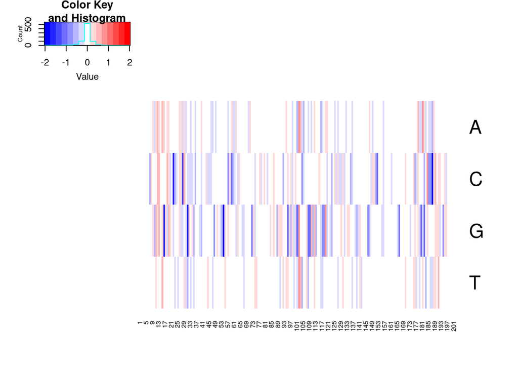

```r
file_mutationMap_large=paste0("results/SNP/mutationMap_",peakSize,"b_",expe,".pdf")
#pdf(file_mutationMap_large,30,4)
heatmap.2(mutationMap, trace="none", scale="none", dendrogram="none", Rowv=FALSE, Colv=FALSE, col=colorRampPalette(colors = c("blue","white","red")))
```

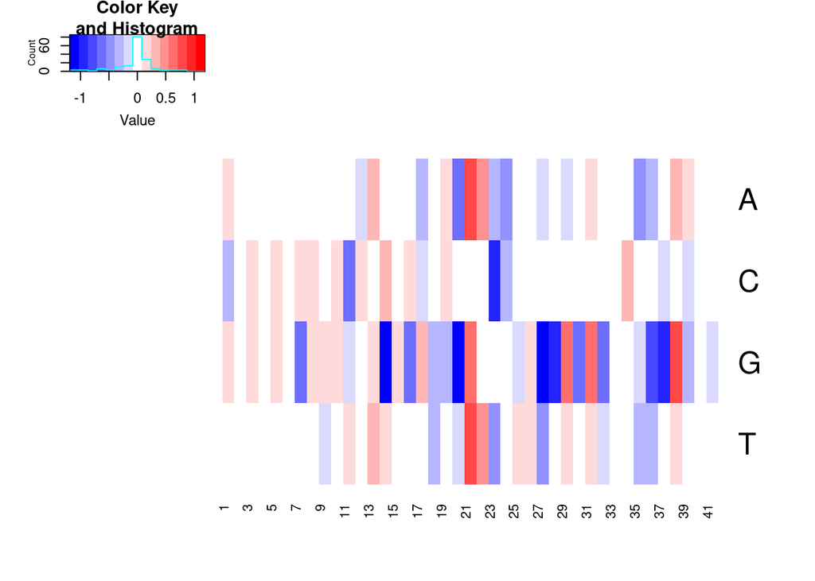

```r
#dev.off()

file_mutationMap_large=paste0("results/SNP/mutationMap_",41,"b_",expe,".pdf")
#pdf(file_mutationMap_large,10,4)
mapRange=(ceiling(peakSize/2)-20):(ceiling(peakSize/2)+20)
heatmap.2(mutationMap[,mapRange], trace="none", scale="none", dendrogram="none", Rowv=FALSE, Colv=FALSE, col=colorRampPalette(colors = c("blue","white","red")))
```

```r
#dev.off()
```